# Desafio VivaReal

Emerson L. Machado

# Código Fonte

[Clique aqui](https://github.com/emada/vivareal) para o ver código fonte.

# Reserva para Validação

Reservei 20% dos dados para validar o modelo ao final da fase de aprendizado. Esse subconjunto servirá para confirmar se o modelo aprendido consegue realmente generalizar para dados não vistos. A motivação é que, mesmo utilizando validação cruzada com repetição, ainda há a chance de o modelo se ajustar aos dados de teste. Isso afeta o poder de generalização do modelo final, produzindo baixo erro na validação cruzada (durante o treinamento) mas alto erro na validação. Só depois que o modelo é aprendido é que utilizo o conjunto de validação para ter uma ideia de como ele se comportará em produção. Caso o modelo não fique bom, recomeço tudo novamente e busco uma nova alternativa.

```r
set.seed(1)
sample_size <- round(0.2 * nrow(train_all))
valid_ind <- sample(1:nrow(train_all), sample_size)
valid_set <- train_all[valid_ind, ]
train_set <- train_all[-valid_ind, ]

# Get numeric factor variables
numeric_variables <- which(mapply(is.numeric, train_set) == TRUE)
factor_variables  <- which(mapply(is.factor, train_set)  == TRUE)
train_set_numeric <- train_set[, numeric_variables]
train_set_factor  <- train_set[, factor_variables]
```

# Análise Exploratória

A base contém 22 variáveis, sendo um identificador `id`, um alvo `target` e as demais anônimas, sem indício do que sejam. Irei desconsiderar a variável `id`, pois ela não fornece nada de valor para a construção do modelo.

```r
train_set[, c("id")] <- NULL
valid_set[, c("id")] <- NULL
names(train_set)
```

```
##  [1] "feature_0"  "feature_1"  "feature_2"  "feature_3"  "feature_4"
##  [6] "feature_5"  "feature_6"  "feature_7"  "feature_8"  "feature_9"
## [11] "feature_10" "feature_11" "feature_12" "feature_13" "feature_14"
## [16] "feature_15" "feature_16" "feature_17" "feature_18" "feature_19"
## [21] "target"
```

```r
str(train_set)
```

```
## 'data.frame':    47587 obs. of  21 variables:
##  $ feature_0 : num  NA NA NA NA NA ...
##  $ feature_1 : Factor w/ 12216 levels "0011625f3f42d82a0b46",..: 5955 5955 12196 1714 10961 5955 12212 5955 5955 5955 ...
##  $ feature_2 : Factor w/ 16794 levels "00023e87f77492abbf89",..: 4444 14153 9476 8187 10249 14153 14153 14153 9197 14153 ...
##  $ feature_3 : Factor w/ 45757 levels "00003e3b9e5336685200",..: 24627 39733 7897 6673 12272 39602 41221 27344 5615 23136 ...
##  $ feature_4 : Factor w/ 2 levels "e546784dabc7c0baa399",..: 1 1 1 1 1 2 2 1 1 1 ...
##  $ feature_5 : Factor w/ 17 levels "124f71327e0b6686ec9a",..: 12 12 12 9 7 17 11 12 6 10 ...
##  $ feature_6 : Factor w/ 3 levels "7c7c704d16a864767fed",..: 3 3 3 3 3 3 3 3 3 3 ...
##  $ feature_7 : num  3.63 1.85 0.72 3.63 3.63 ...
##  $ feature_8 : int  128 28 348 294 297 331 327 132 177 69 ...
##  $ feature_9 : num  6.107 0.72 0.143 0.72 0.143 ...
##  $ feature_10: num  -27.6 NA NA NA -25.4 ...
##  $ feature_11: int  10 2 24 20 20 22 22 10 12 6 ...
##  $ feature_12: num  56688 3940 2256 384837 111346 ...
##  $ feature_13: Factor w/ 1 level "18ff74f43da410c5529f": 1 1 1 1 1 1 1 1 1 1 ...
##  $ feature_14: num  56688 3940 2256 384837 111346 ...
##  $ feature_15: num  0.72 0 0 3.63 1.85 ...
##  $ feature_16: num  -48.5 NA NA NA -49.3 ...
##  $ feature_17: Factor w/ 20300 levels "000911851869bed6efe3",..: 8815 13095 759 2333 6975 13095 5741 4077 13095 13095 ...
##  $ feature_18: Factor w/ 3 levels "3fc2c3cbe8987c1a067e",..: 2 2 2 2 2 2 2 2 2 2 ...
##  $ feature_19: Factor w/ 3 levels "5fb1f955b45e38e31789",..: 1 3 1 1 3 1 1 1 3 3 ...
##  $ target    : num  39.4 30.7 28.4 43.4 37.2 ...
```

Como visto acima, existem 10 variáveis categóricas e 12 variáveis numéricas. Para uma exploração inicial, irei focar primeiramente somente nas variáveis numéricas.

## Análise Exploratória das Variáveis Numéricas

Veja a seguir o sumário das variáveis numéricas. Interessante observar a quantidade de valores faltantes nas variáveis `feature_0`, `feature_10`, `feature_12` e `feature_16`. A variável `feature_0` chega a ter `89%` de valores faltantes. Irei lidar com esse problema mais a diante.

```r
apply(train_set_numeric, 2, summary)
```

```
## $id
##    Min. 1st Qu.  Median    Mean 3rd Qu.    Max.
##       1   19810   39650   39630   59380   79310
##
## $feature_0
##      Min.   1st Qu.    Median      Mean   3rd Qu.      Max.      NA's
##         0     17080    221700   2947000   1117000 899500000     42436
##
## $feature_7
##     Min.  1st Qu.   Median     Mean  3rd Qu.     Max.
##     0.00     0.14     0.72     2.42     1.85 43990.00
##
## $feature_8
##    Min. 1st Qu.  Median    Mean 3rd Qu.    Max.
##       1      73     128     163     267     365
##
## $feature_9
##     Min.  1st Qu.   Median     Mean  3rd Qu.     Max.
##   0.0000   0.0000   0.1429   0.9552   0.7200 781.7000
##
## $feature_10
##    Min. 1st Qu.  Median    Mean 3rd Qu.    Max.    NA's
##  -53.09  -27.45  -26.39  -27.04  -25.44   62.55   25076
##
## $feature_11
##    Min. 1st Qu.  Median    Mean 3rd Qu.    Max.
##    2.00    6.00   10.00   11.71   18.00   24.00
##
## $feature_12
##      Min.   1st Qu.    Median      Mean   3rd Qu.      Max.      NA's
## 0.000e+00 1.786e+03 5.186e+03 1.052e+25 2.256e+04 3.078e+29     18336
##
## $feature_14
##      Min.   1st Qu.    Median      Mean   3rd Qu.      Max.
## 0.000e+00 1.566e+03 5.459e+03 6.468e+24 3.188e+04 3.078e+29
##
## $feature_15
##      Min.   1st Qu.    Median      Mean   3rd Qu.      Max.
##      0.00      0.00      0.00      3.95      0.14 169400.00
##
## $feature_16
##    Min. 1st Qu.  Median    Mean 3rd Qu.    Max.    NA's
##  -60.67  -49.34  -49.24  -48.83  -48.63  106.80   25077
##
## $target
##    Min. 1st Qu.  Median    Mean 3rd Qu.    Max.
##    9.00   28.95   31.36   32.00   34.52   71.22
```

### Análise Univariada

Observar que a maioria das variáveis númericas possuem distribuições que diferem da normal.

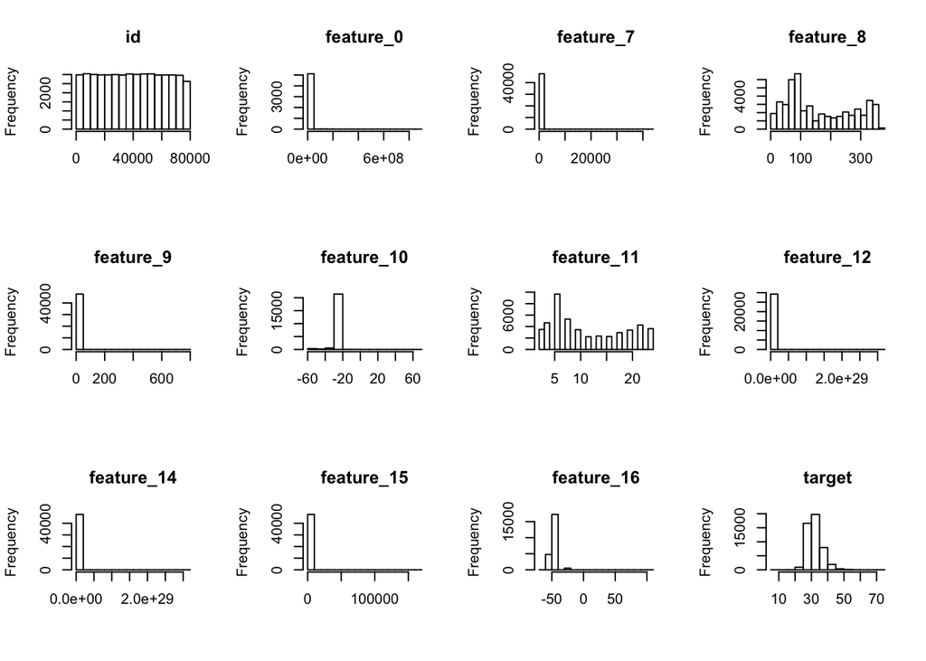

```r
par(mfrow=c(3,4))
for (i in 1:ncol(train_set_numeric)) {
  hist(train_set_numeric[, i], main=names(train_set_numeric)[i], xlab="")
}
```

A uma primeira impressão, as variáveis parecem ser da seguinte forma:

- exponencial: `feature_0`, `feature_7`, `feature_9`, `feature_12`, `feature_14` e `feature_15`
- bimodal: `feature_8` e `feature_11`
- normal com assimetria positiva: `target` e talvez `feature_16`
- laplaciana: `feature_10`

Ajustando os intervalos de cada histograma, algumas características interessantes são ressaltadas. Nos histogramas que mostro a seguir, cada valor único foi representado em um único intervalo.

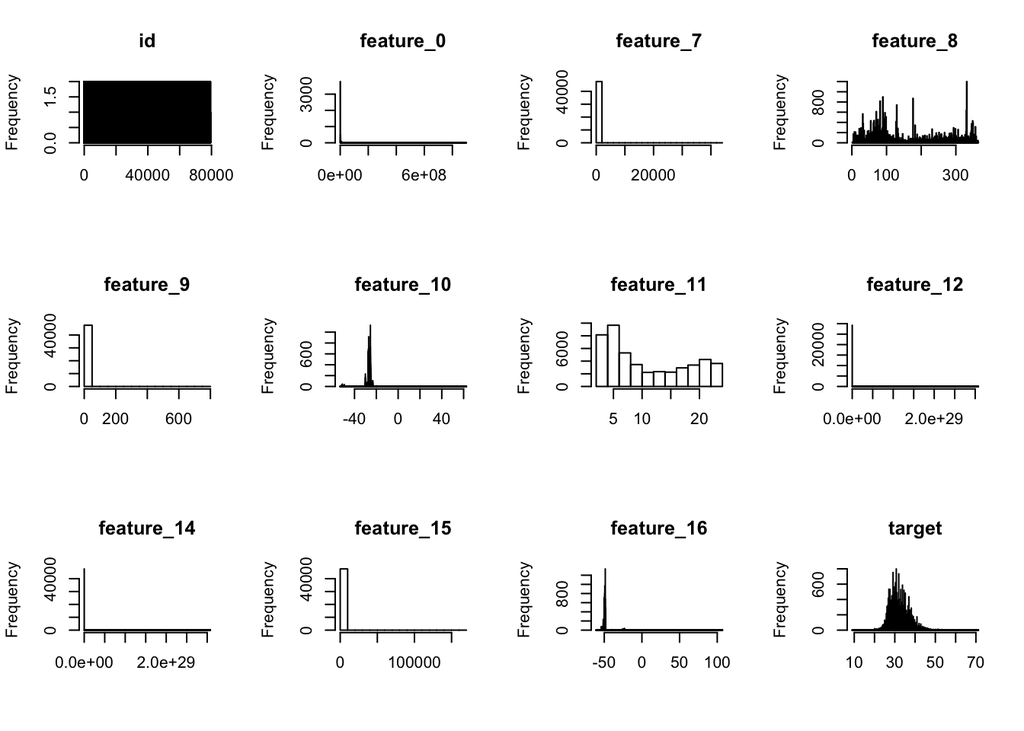

```r
par(mfrow=c(3,4))
for (i in 1:ncol(train_set_numeric)) {
  hist(train_set_numeric[, i], main=names(train_set_numeric)[i], breaks=length(unique(train_set_numeric[, i])), xlab="")
}
```

Os histogramas acima reforçam a maioria das minhas suspeitas:

- exponencial: `feature_0`, `feature_7`, `feature_9`, `feature_12`, `feature_14` e `feature_15`
- bimodal: `feature_8` e `feature_11`
- normal com assimetria positiva: `target`
- laplaciana: `feature_10` e `feature_16`

A `feature_16` que parecia uma normal com assimetria positiva se mostrou mais uma laplaciana com a nova configuração de intervalos. Plotando a densidade dessas distribuições, pode ser que algo relevante se mostre.

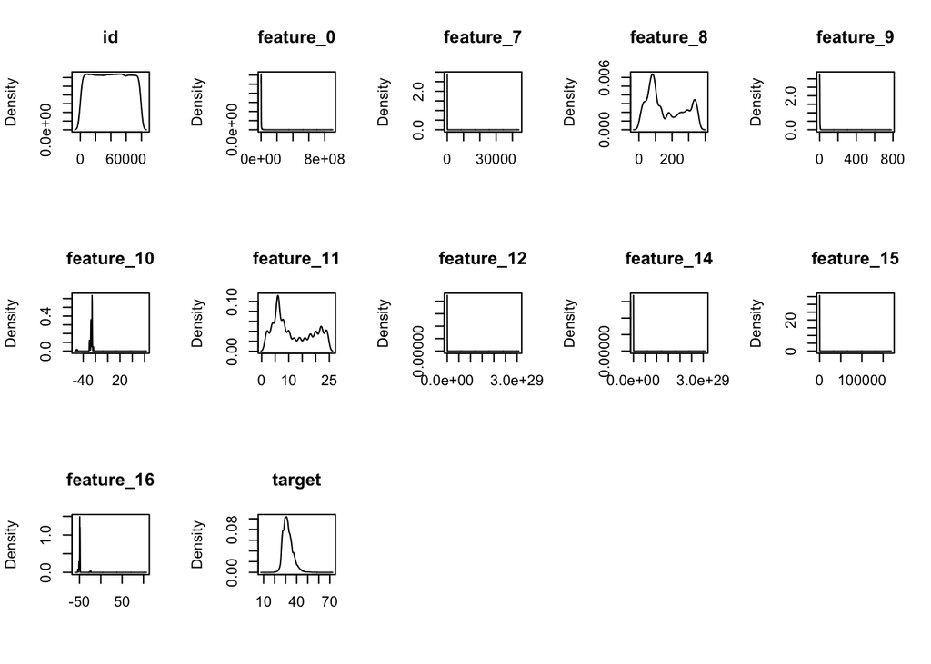

Os gráficos acima com as densidades das variáveis são claros. É realmente provável que as distribuições seja as que indiquei acima.

### Análise Multivariada

É interessante ter uma ideia de como as variáveis se relacionam entre si. A função `pairs` permite visualizar o comportamento de cada par de variável.

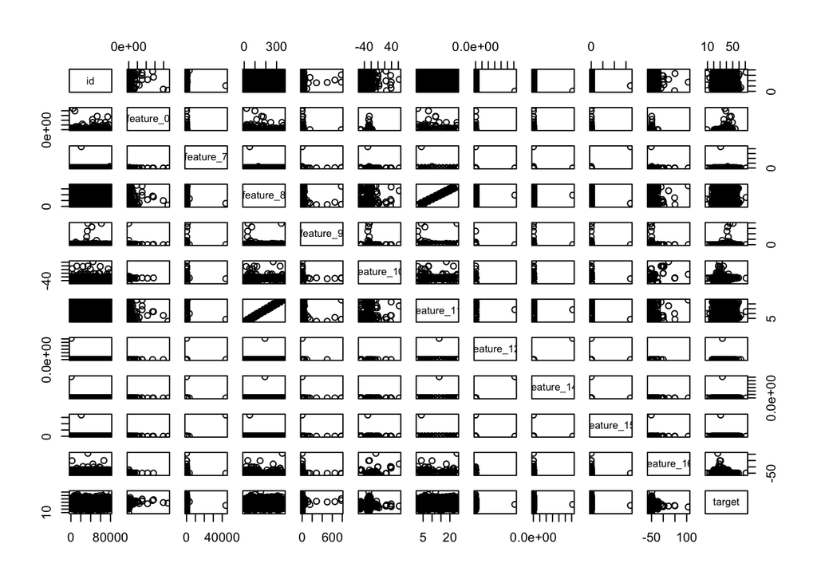

```r
pairs(train_set_numeric)
```

Interessante notar o padrão linear entre as variáveis `feature_8` e `feature_11`. Até parecem iguais. Analisando mais atentamente seus histogramas e gráficos de função de densidade, percebe-se que realmente parecem serem amostras de uma mesma distribuição. Entretanto, ambas diferem na escala e a variável `feature_11` possui apenas valores discretos.

```r
sort(unique(train_set_numeric$feature_11))
```

```
##  [1]  2  4  6  8 10 12 14 16 18 20 22 24
```

Observe também os pares formados pelas variáveis `feature_0`, `feature_7`, `feature_9`, `feature_10`, `feature_12`, `feature_14`, `feature_15` e `feature_16`. Grande parte delas possuem relação linear.

Observe também como a variável `target` se relaciona com as variáveis `feature_7`, `feature_9`, `feature_12`, `feature_14`, `feature_15`. Parece que elas sozinhas explicam boa parte da variância da variável `target`.

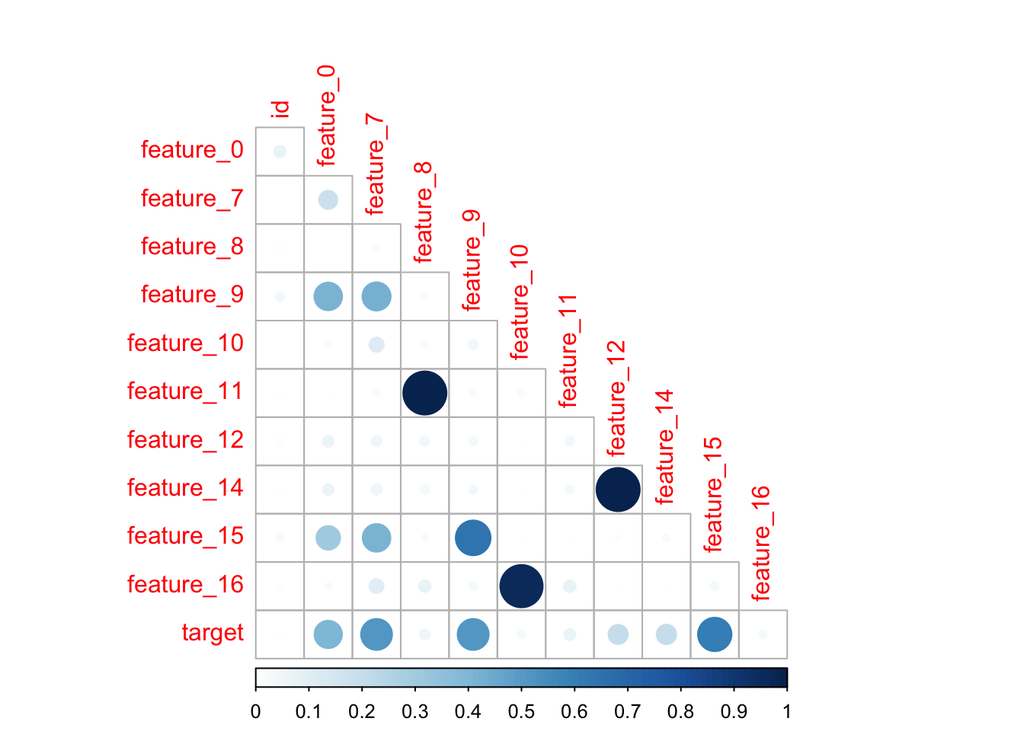

### Pré-processamento das Variáveis Numéricas

A seguir, mostro os histogramas e funções de densidade das variáveis transformadas. A transformação que utilizei é a `YeoJohnson`, uma variante da `Box-Cox` que aceita valores nulos e negativos. Não apliquei apliquei às variáveis que aparentam ser bimodais (`feature_8` e `feature_11`). Para cada variável, a primeira linha correspnde aos valores originais e a segunda aos valores transformados.

```
## [1] "feature_0"
```

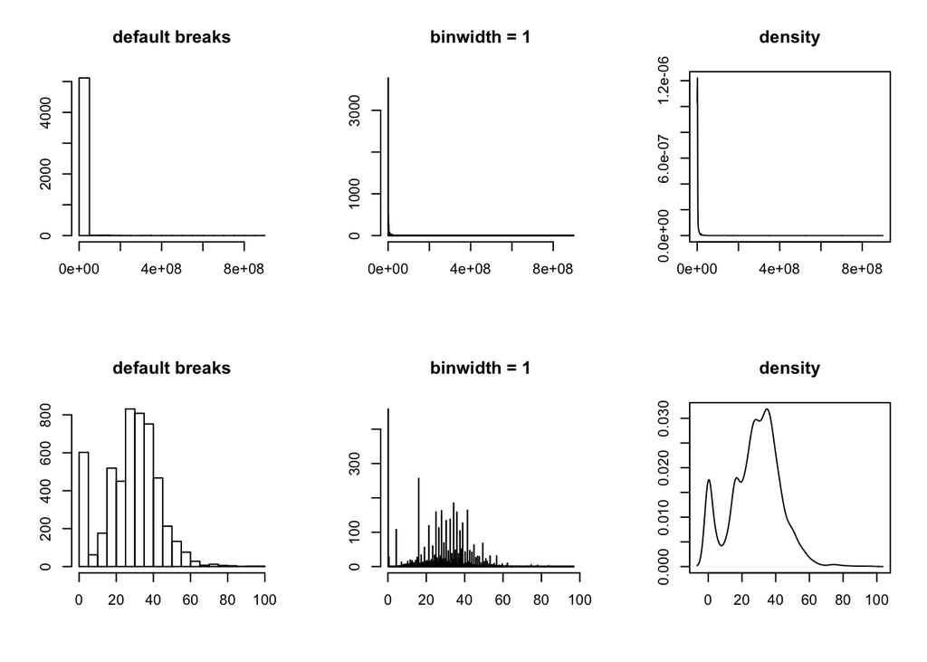

```
## [1] "feature_7"
```

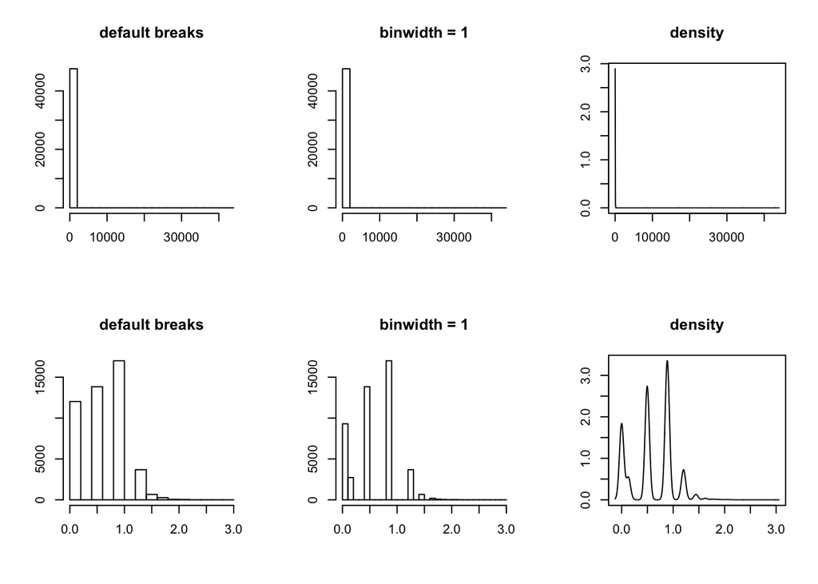

```
## [1] "feature_9"
```

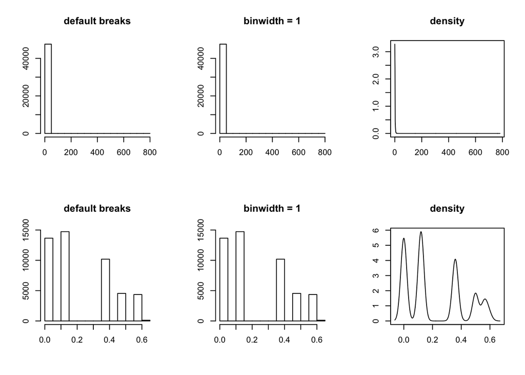

```
## [1] "feature_10"
```

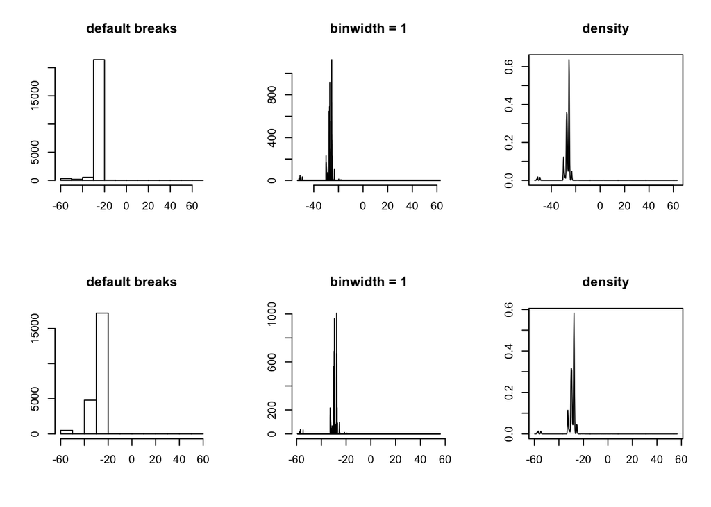

```
## [1] "feature_12"
```

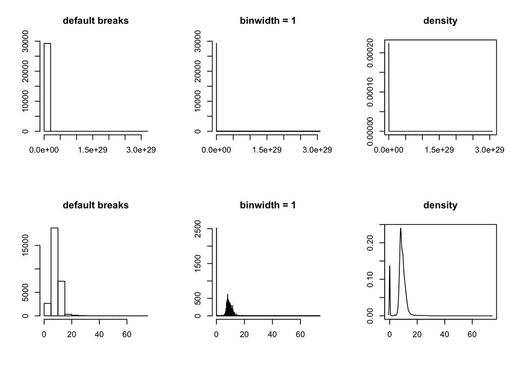

```
## [1] "feature_14"
```

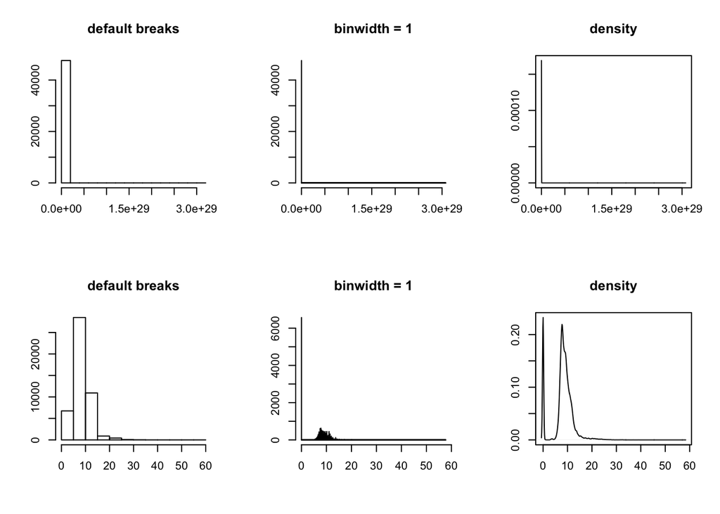

```
## [1] "feature_15"
```

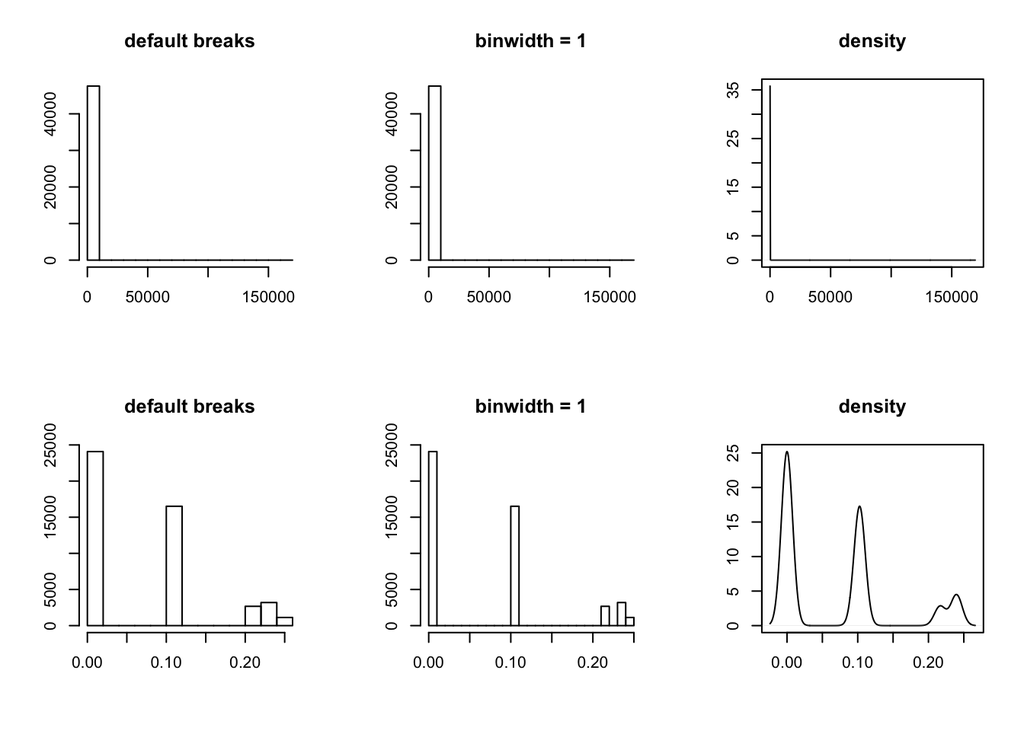

```
## [1] "feature_16"
```

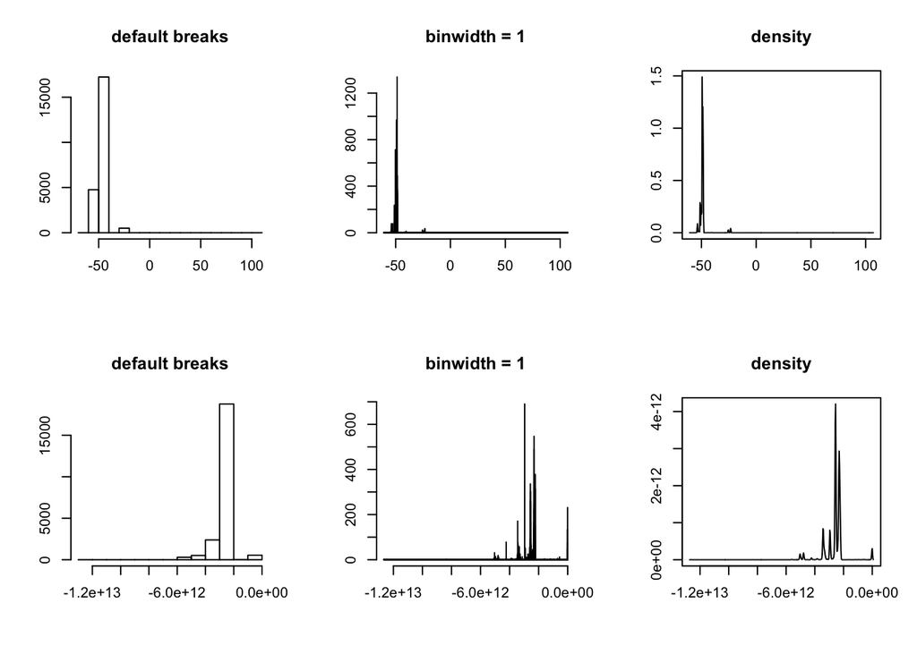

Apresento a seguir o gráfico da correlação entre as variáveis transformadas. A julgar por esse gráfico, a transformação que apliquei aumentou a correlação entre as variáveis e entre as variáveis e a variável `target`.

#### Correlação Dados Originais

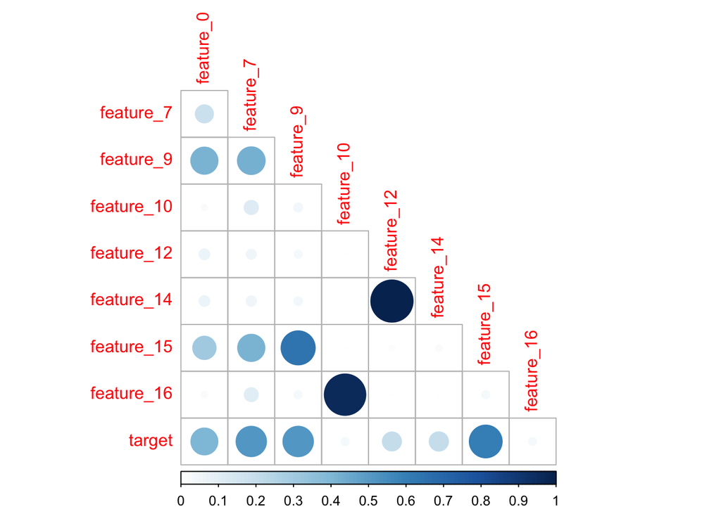

#### Correlação Dados Transformados

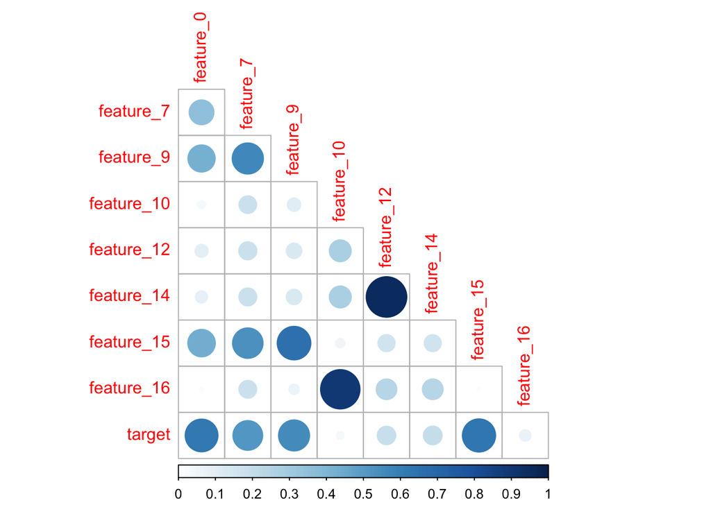

## Análise Exploratória das Variáveis Categóricas

Voltando agora para as variáveis categóricas, observe que algumas delas possuem um número altíssimo de níveis e uma delas possui apenas um nível.

```r
for (i in 1:length(train_set_factor)) {
  col <- train_set_factor[, i]
  print(paste(names(train_set_factor)[i], length(unique(col))))
}
```

```
## [1] "feature_1 10794"
## [1] "feature_2 13947"
## [1] "feature_3 37723"
## [1] "feature_4 2"
## [1] "feature_5 17"
## [1] "feature_6 3"
## [1] "feature_13 1"
## [1] "feature_17 17295"
## [1] "feature_18 3"
## [1] "feature_19 3"
```

Variáveis categóricas com alto número de níveis afetam negativamente métodos baseados em árvore de decisão, pois o método terá que testar $2^n$ possíveis cortes para $n$ níveis em cada galho da árvore onde a variável for testada.

### Pré-processamento das Variáveis Categóricas

Para uma primeira análise, irei remover essas variáveis destoantes.

```r
remove_id <- c("feature_1", "feature_2", "feature_3", "feature_13", "feature_17")
train_set[, remove_id] <- NULL
valid_set[, remove_id] <- NULL
numeric_variables <- which(mapply(is.numeric, train_set) == TRUE)
factor_variables  <- which(mapply(is.factor, train_set)  == TRUE)
train_set_numeric <- train_set[, numeric_variables]
train_set_factor  <- train_set[, factor_variables]
```

Subsequentemente, poderei voltar à essas variáveis que exclui e processá-las de forma apropriada possivelmente:

- trocando as pelas suas frequências
- trocando as pela média e variância da variável `target`
- combinação das duas acima

## Valores Faltantes

A base de dados fornecida contém diversos valores faltantes, como mostrado no mapa a seguir.

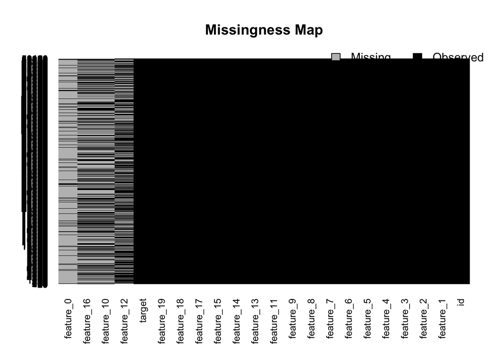

A quantidade de casos com um ou mais valores faltantes é extremamente alto, chegando a mais de 99% dos dados.

```
## [1] "Todos: 59484"
```

```
## [1] "Casos completos (sem nenhum valor faltante): 460"
```

```
## [1] "Proporção desses casos na base: 0.77%"
```

O pacote CARET do R fornece três métodos para imputar valores faltantes: `medianImpute`, `knnImpute` e `bagImpute`. Avaliarei esses métodos durante a construção do modelo, onde essas técnicas serão utilizadas para completar valores faltantes a cada passo da validação cruzada.

# Ajuste de Modelos

Utilizei o pacote CARET do R para avaliar o desempenho das técnicas de pré-processamento e de modelagem que selecionei. Para uma primeira rodada do ciclo de construção do modelo, utilizei os pré-processamentos:

- medianImpute
- YeoJohnson

Utilizei os seguintes métodos para a modelagem dos dados:

- ranger - Random Forest
- glm - Generalized Linear Model
- xgbTree - Extreme Gradient Tree Boosting

Utilizei validação cruzada com 5 dobras e 3 repetições. Como a base é relativamente pequena, com mais tempo eu optaria por utilizar mais dobras. Utilizei as opções *default* dos métodos configuradas no pacote CARET.

A métrica utilizada no desafio é a mediana do absoluto da diferença entre o erro e valor predito.
$$Erro = \text{mediana}(\text{abs}(y_{true} - y_{pred}) / y_{true} )$$

Portanto, alterei a métrica do CARET para

```r
medianSummary <- function (data, lev=NULL, model=NULL) {
  out <- median(abs(data$obs - data$pred) / data$obs)
  names(out) <- "MED"
  out
}
```

Veja na seguinte figura os resultados obtidos com essa métrica. Os nomes dos modelos são formados pela concatenção do nome do método utilizado seguido pelo(s) pré-processamento(s) utilizado(s).

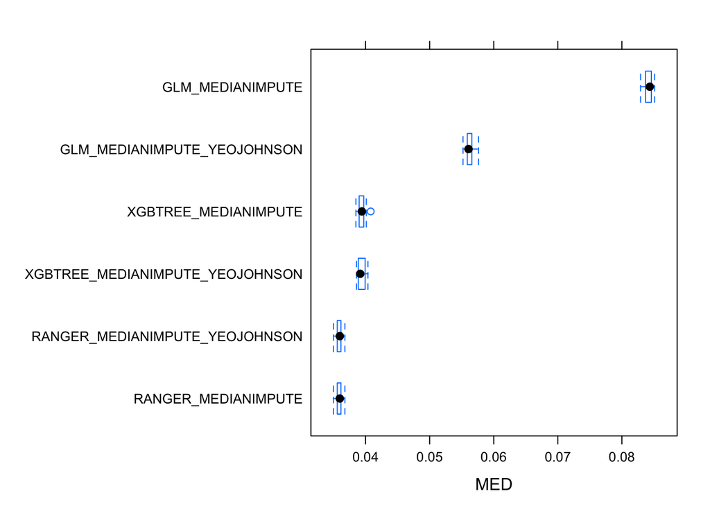

Observe que o pré-processamento `YeoJohnson` diminui bastante o erro mediano do modelo gerado com `glm`. Isso já não acontece nos modelos gerados com `xgbTree` e `ranger`, possivelmente por esses métodos serem menos sensíveis ao tipo de distribuição das variáveis preditoras.

Observe também como os modelos gerados com `ranger` e `xgbTree` superaram os demais. Esse baixo erro mediano absoluto tem como preço um alto custo computacional. Veja a seguir um gráfico de dispersão do erro mediano absoluto versus o tempo gasto para se gerar o modelo.

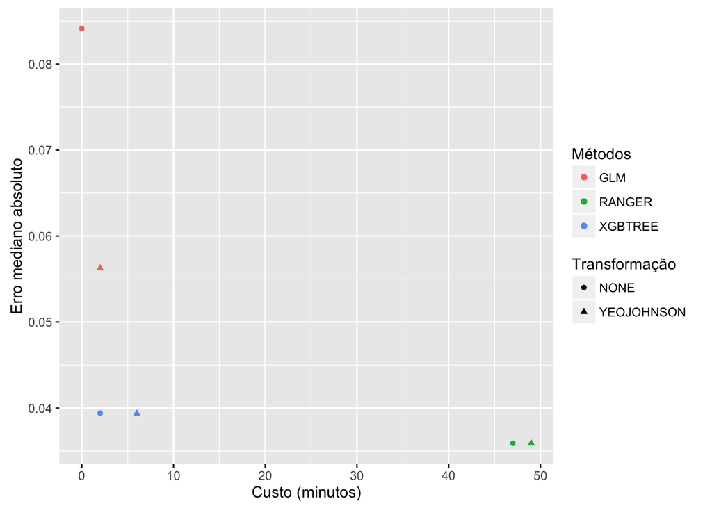

Observe que os dois modelos que levaram mais de 45 minutos para serem aprendidos foram os realizados com o método `ranger`. Se fosse para escolher apenas um método para continuar a ajustar o modelo, eu escolheria o `xgbTree`. Mesmo que o `ranger` tenha gerado modelos com erros mais baixos, o método `xgbTree` possui uma gama maior de parâmetros para serem explorados e o seu tempo de execução é consideravelmente menor que o do `ranger`, chegando a 25 vezes mais rápido nos testes que fiz (não levando em conta o tempo de execução do pré-processamento).

Os próximos passos seriam explorar mais os parâmetros de cada método de forma a aprimorar o ajuste dos modelos aos dados. Como esse desfaio contempa apenas uma visão geral dos passos de ajuste de modelo, finalizo aqui a fase de exploração da construção do modelo.

# Construção do Modelo Final e sua Validação

Para finalizar, escolho os parâmetros que gerou o modelo com o menor erro mediano absoluto. Dentre os modelos que gerei, irei utilizar os parâmetros do modelo gerado pelo método `ranger` com pré-processamento `medianImpute`.

```r
train_set <- train_all[-valid_ind, ]
dummies <- dummyVars(~ ., data=train_set, levelsOnly=FALSE)
train_set <-  as.data.frame(predict(dummies, newdata=train_set))
preprocessParams <- preProcess(train_set, method="medianImpute")
train_set <- predict(preprocessParams, train_set)

valid_set <- train_all[valid_ind, ]
valid_set <-  as.data.frame(predict(dummies, newdata=valid_set))
valid_set <-  predict(preprocessParams, newdata=valid_set)

fit <- ranger(target ~ ., data=train_set, mtry=mtry, write.forest=TRUE, importance='impurity')
```

Observe no gráfico a seguir a contribuição (média) da importância de cada variável na predição dos valores da variável `target`. Essa informação é interessante para a fase de engenharia de características (do inglês, *feature engineering*) de métodos que não possuem mecanismo interno de seleção de variáveis. Claro que o impacto no modelo dessa seleção de características deve ser estimada com validação cruzada. Nessa figura, condensei as variáveis que possuem valores abaixo de 0.5% em apenas uma com o rótulo `Demais`.

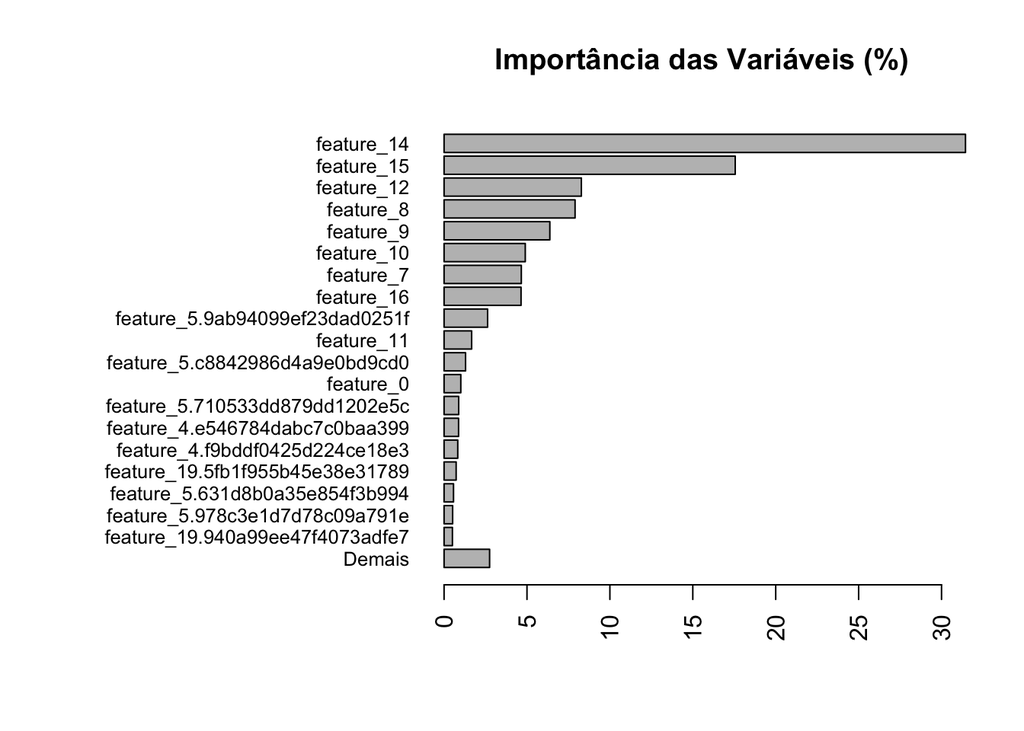

Por fim, o erro mediano absoluto estimado com os casos que reservei do conjunto de treinamento (20%) é

```
## [1] "Erro mediano absoluto: 0.0357"
```

que é condizente com o erro estimado durante a validação cruzada. Portanto, esse modelo aparenta não estar sobreajustado aos casos de treinamento e é um bom candidato para ser colocado em produção.

Os valores preditos para a variável target to arquivo `test.csv` estão gravados no arquivo `test_predictions.csv`.